# TRIP ADVISER REVIEW ANALYSIS

As part of this analysis, we analyze the Hotel reviews from **Tripadviser**. we could find the [Trip Adviser dataset here](https://github.com/kavgan/OpinRank). This analysis is focused to **TF-IDF** technique.

```python
# Required Packages

from collections import Counter, defaultdict
from scipy.sparse import lil_matrix, spmatrix, csr_matrix, save_npz, load_npz
import matplotlib.pyplot as plt
import numpy as np
import string
import os
import re
import pandas as pd
```

## Data Filter Information

Reviews are available for lot of cities. But for analysis and fast process, limited data to the **beijing** city hotels.

```python
#Selecting cities and data path
DataPath="E:\Techi\Courses\Masters in Data Science\Courses\Text Visualization\Data sets\Trip Advisor\hotels\data\\"
Cities=['beijing'] #, 'chicago', 'dubai', 'las-vegas', 'london', 'montreal', 'new-delhi', 'new-york-city', 'san-francisco', 'shanghai']
```

## Data Normalization & TF_IDF Process

### Trimming

- We removed the *white space, punctuation, numbers and Special Character*

### TFID Generation & Print

- tf_idf function will result the all TF-IDF features and print_tf_idf function will display the results in elegant way

```python
# Taken from Gensim preparators
RE_PUNCT = re.compile(r'([%s])+' % re.escape(string.punctuation), re.UNICODE)
RE_NUMERIC = re.compile(r"[0-9]+", re.UNICODE)
RE_NONALPHA = re.compile(r"\W", re.UNICODE)
RE_WHITESPACE = re.compile(r"(\s)+", re.UNICODE)
MIN_LENGTH = 3

# Function definition

def normalise(s):
    if s is None or s is np.nan:
        return ""
    s = s.lower()
    s = RE_PUNCT.sub(" ", s)
    s = RE_WHITESPACE.sub(" ", s)
    s = RE_NUMERIC.sub("", s)
    s = ' '.join([w for w in s.split() if len(w)>=MIN_LENGTH])
    s = RE_NONALPHA.sub(" ", s)
    return s

def tf_idf(vectors: spmatrix, i: int):
    tf_max = vectors[i].data.max()
    tokens = []
    for wi, val in zip(vectors[i].indices,
                       vectors[i].data):

        token = inverse_vocab[wi][0]
        unique_tokens = vectors[i].getnnz()
        token_cnt_global = inverse_vocab[wi][1]
        tf = val
        tf_norm = 0.5+0.5*(tf/tf_max)
        token_n_docs = vectors.T[wi].getnnz()
        idf = np.log(vectors.shape[0]/token_n_docs)
        tokens.append((token, wi, token_cnt_global, tf, token_n_docs, idf, tf*idf, tf_norm*idf))
    return sorted(tokens, key=lambda t: t[7], reverse=True)

def print_tf_idf(vectors:spmatrix, i: int, limit=None):
    print('TOKEN       | TOKEN CNT | TF | TF_normed | IDF | TF_IDF | TF_IDF_normed')
    for t, wi, tcg, tc, tnd, i, ti, tni in tf_idf(vectors, i)[:limit]:
        print(f'{t:<15} | {wi} | {tcg} | {tc} | {tnd} | {i:.4f} | {ti:.4f} | {tni:.4f}')
```

## Data Retrivel and Processing

Below code collect reviews from all files and append it.

```python
Dataset=pd.read_csv("E:\Techi\Courses\Masters in Data Science\Courses\Text Visualization\Data sets\Trip Advisor\hotels\data\\test", names=['Date','Title','Content'], delimiter="\t", index_col=3, encoding = "ISO-8859-1")
Dataset["City"]="Test"
Dataset.reset_index()
for city in Cities :
    print("Started : "+city)
    for i in os.listdir(DataPath+city+"\\"):
        try :
            Dataset2=pd.read_csv(DataPath+city+"\\"+i, names=['Date','Title','Content'], delimiter="\t", index_col=3, encoding = "ISO-8859-1")
            Dataset2.reset_index()
            Dataset2["City"]=city
            Dataset2["Hotel"]=i
            Dataset=pd.concat([Dataset,Dataset2],ignore_index=True,axis=0, sort=True)
        except :
            print(city+"\\"+i+" file is corrupted")
    print("Completed : "+city)
```

```
Started : beijing
Completed : beijing
```

```python
Dataset["Date"]=pd.to_datetime(Dataset["Date"])
Dataset.index=Dataset.Date
Dataset["Year"]=Dataset.index.year
Dataset["Month"]=Dataset.index.month
```

### Below are the 20 most reviewed hotels in Beijling

```python
#Top 20 most reviewed hotels
Counter(Dataset.Hotel).most_common(20)
```

[output not shown]

#### Totally 5254 reviews from 136 hotels

```python
len(Dataset)
```

```
5254
```

#### We create default vocubulary list and increasing frequency as per the review text

```python
#Normalising
Dataset["NormalisedContent"] = Dataset["Content"].apply(normalise)
full_vocab = defaultdict(int)
i=0
for review in Dataset["NormalisedContent"] :
    i=i+1
    if review!="":
        for token in review.split():
            full_vocab[token] += 1
```

```python
full_vocab_c=Counter(full_vocab)
size_full_vocab = len(full_vocab)
```

#### Below 20 words are most used words in review

```python
full_vocab_c.most_common(20)
```

```
[('the', 60002),
 ('and', 30579),
 ('was', 15478),
 ('hotel', 13591),
 ('for', 10455),
 ('you', 7881),
 ('with', 7218),
 ('very', 6795),
 ('but', 6499),
 ('room', 6457),
 ('this', 6236),
 ('were', 6111),
 ('that', 6008),
 ('not', 5591),
 ('are', 5208),
 ('there', 4964),
 ('had', 4493),
 ('from', 4313),
 ('beijing', 4152),
 ('have', 4080)]
```

#### Below 20 words are least used words in review

```python
# least popular tokens
full_vocab_c.most_common(size_full_vocab)[-20:]
```

```
[('qinchunjiari', 1),
 ('leena', 1),
 ('witty', 1),
 ('competant', 1),
 ('pickled', 1),
 ('frill', 1),
 ('jon', 1),
 ('mote', 1),
 ('channls', 1),
 ('englishbreakfast', 1),
 ('horribleoverall', 1),
 ('undesirable', 1),
 ('trembling', 1),
 ('alight', 1),
 ('aircondioning', 1),
 ('disk', 1),
 ('stairwells', 1),
 ('supemarket', 1),
 ('hendersen', 1),
 ('footbridge', 1)]
```

```python
cnt = [c for _, c in full_vocab_c.most_common(size_full_vocab)]
```

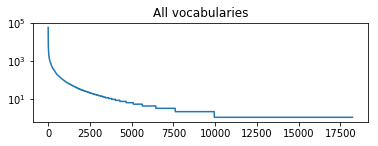

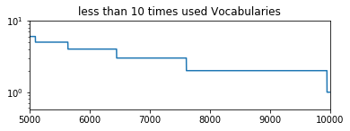

```python
#Vocubulary usage
plt.subplot(2,1,1)
plt.plot(cnt)
plt.yscale('log')
plt.title("All vocabularies")
plt.show()

plt.subplot(2,1,2)
plt.plot(cnt)
plt.yscale('log')
plt.title("less than 10 times used Vocabularies")
plt.ylim((0,10))
plt.xlim((5000,10000))
plt.show()
```

**Creating a list of numbers for each sentence and hotels :**

```python
fixed_vocab = {w: (i, c) for i, (w, c) in enumerate(full_vocab_c.most_common(size_full_vocab)[5000:136262])}
fixed_vocab_size = len(fixed_vocab)
inverse_vocab = {i: (w, c) for w, (i, c) in fixed_vocab.items()}

num_top_hotel = 500
top_hotel = {s: (i, c) for i, (s, c) in enumerate(Counter(Dataset['Hotel']).most_common(num_top_hotel))}
inverse_hotel = {i: (s, c) for s, (i, c) in top_hotel.items()}

# number of speech parts:
num_parts = len(Dataset["NormalisedContent"])

review_vectors = lil_matrix((num_parts, fixed_vocab_size), dtype=np.int16)
hotel_vectors = lil_matrix((num_top_hotel, fixed_vocab_size), dtype=np.int16)
```

```python
#print(len(fixed_vocab)) #Not often words
#print(len(full_vocab)) #All words
print("Most used vocab : "+str(round((len(full_vocab)-len(fixed_vocab))/len(full_vocab)*100,2))+"%")
```

```
Most used vocab : 27.42%
```

**Removing non vocabulary words from review content :**

```python
# remove out of vocab words from text
for i, part_text in enumerate(Dataset["NormalisedContent"]):
    Dataset["NormalisedContent"][i] = ' '.join([w for w in part_text.split() if w in fixed_vocab])
```

**Creating a frequency for review vocabulary :**

```python
# build vectors
for i, part_text in enumerate(Dataset["NormalisedContent"]):
    if (i % 1000) == 0:
        print(f'Processed {i}/{num_parts} reviews...')

    hotel_id = top_hotel.get(Dataset["Hotel"][i], None)

    for token in Dataset['NormalisedContent'][i].split():
        token_id = fixed_vocab[token][0]
        review_vectors[i, token_id] += 1
        if hotel_id is not None:
            hotel_vectors[hotel_id[0], token_id] += 1
```

```python
# Compressing Matrix
review_vectors=review_vectors.tocsr()
hotel_vectors=hotel_vectors.tocsr()
```

## Hotel name and review count :

```python
for ki in inverse_hotel:
    print(f'{ki}: {inverse_hotel[ki][0]} has {inverse_hotel[ki][1]} Reviews')
```

```
0: china_beijing_park_plaza_beijing_wangfujing has 262 Reviews
1: china_beijing_holiday_inn_central_plaza has 230 Reviews
2: china_beijing_the_peninsula_beijing has 194 Reviews
3: china_beijing_grand_hyatt_beijing has 179 Reviews
4: china_beijing_crowne_plaza_hotel_beijing has 126 Reviews
5: china_beijing_novotel_peace_hotel has 110 Reviews
6: china_beijing_novotel_xinqiao_beijing has 108 Reviews
7: china_beijing_hotel_g has 104 Reviews
8: china_beijing_days_inn_forbidden_city_beijing has 99 Reviews
9: china_beijing_kapok_hotel has 96 Reviews
10: china_beijing_the_regent_beijing has 88 Reviews
11: china_beijing_courtyard_by_marriott has 80 Reviews
12: china_beijing_grand_mercure_hotel_xidan has 80 Reviews
13: china_beijing_raffles_beijing_hotel has 77 Reviews
14: china_beijing_the_st_regis_beijing has 76 Reviews
```

[output cut: 121 more lines]

## Top 50 most reviewed hotel and TF-IDF Value

**This code and graph depicts the top 50 most reviewed hotels and TF-IDF Values**

But we could not get context of the keyword for particular Hotel. For example, **towelchange** is metioned in some hotels but we are not sure whether is it giving positive feedback or negative feedback.

```
0: china_beijing_park_plaza_beijing_wangfujing,1: china_beijing_holiday_inn_central_plaza,2: china_beijing_the_peninsula_beijing,3: china_beijing_grand_hyatt_beijing,4: china_beijing_crowne_plaza_hotel_beijing,5: china_beijing_novotel_peace_hotel,6: china_beijing_novotel_xinqiao_beijing,7: china_bei…
done
200
```

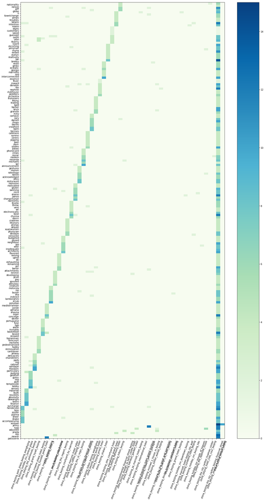

```python
HotelScores1 = []
Hotel1 = range(0,50)
for hi in Hotel1:
    print(f'{hi}: {inverse_hotel[hi][0]},', end='')
    HotelScores1.append(tf_idf(hotel_vectors, hi))
print('\ndone')
select_wi1 = []
sorted_wi1 = []
tmp1 = lil_matrix((len(Hotel1),fixed_vocab_size), dtype=np.float)

for km, ks in enumerate(HotelScores1):
    for hi in ks[:8]:
        select_wi1.append(hi[1])
        if hi[1] not in sorted_wi1:
            sorted_wi1.append(hi[1])
        tmp1[km, hi[1]] = hi[7]

#select_wi=list(set(select_wi))
select_wi1 = [wi for wi,_ in Counter(select_wi1).most_common(200)]
print(len(select_wi1))
fig= plt.figure(figsize=(20,35))
ax = fig.add_subplot(1,1,1)
v4=hotel_vectors[:,select_wi1][Hotel1].toarray().T
plt.pcolormesh(v4, cmap=plt.cm.GnBu)
plt.yticks(np.arange(v4.shape[0]), [inverse_vocab[wi][0] for wi in csr_matrix(tmp1.sum(axis=0)).indices])
plt.xticks(np.arange(len(Hotel1)), [inverse_hotel[ki][0] for ki in Hotel1], rotation=70)
plt.colorbar()
fig.patch.set_facecolor('#FFFFFF')
plt.show()
```

# Low Rated Hotels (< 3.5)

Due to the above reason, we took low rated hostel reviews and built the same graph. we have choosed below hotels which are having less than 3.5 rating out of 5.

- 53: china_beijing_beijing_hotel
- 56: china_beijing_gloria_plaza_hotel_beijing
- 59: china_beijing_grand_view_garden_hotel
- 65: china_beijing_nikko_new_century_beijing_hotel
- 72: china_beijing_new_world_hotel_jing_guang
- 87: china_beijing_days_inn_joiest_beijing
- 97: china_beijing_guangzhou_hotel
- 117: china_beijing_city_hotel_beijing
- 122: china_beijing_hebei_hotel_beijing
- 125: china_beijing_somerset_zhongguancun
- 130: china_beijing_hollyear_hotel_beijing

```
53: china_beijing_beijing_hotel,56: china_beijing_gloria_plaza_hotel_beijing,59: china_beijing_grand_view_garden_hotel,65: china_beijing_nikko_new_century_beijing_hotel,72: china_beijing_new_world_hotel_jing_guang,87: china_beijing_days_inn_joiest_beijing,97: china_beijing_guangzhou_hotel,117: china…
done
88
```

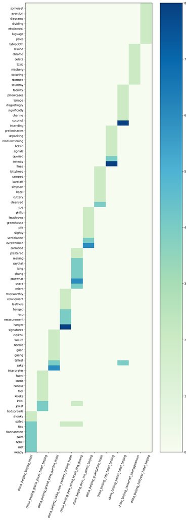

```python
HotelScores1 = []
Hotel1 = [53,56,59,65,72,87,97,117,122,125,130]
for hi in Hotel1:
    print(f'{hi}: {inverse_hotel[hi][0]},', end='')
    HotelScores1.append(tf_idf(hotel_vectors, hi))
print('\ndone')
select_wi1 = []
sorted_wi1 = []
tmp1 = lil_matrix((len(Hotel1),fixed_vocab_size), dtype=np.float)
for km, ks in enumerate(HotelScores1):
    for hi in ks[:8]:
        select_wi1.append(hi[1])
        if hi[1] not in sorted_wi1:
            sorted_wi1.append(hi[1])
        tmp1[km, hi[1]] = hi[7]

#select_wi=list(set(select_wi))
select_wi1 = [wi for wi,_ in Counter(select_wi1).most_common(500)]
print(len(select_wi1))

fig= plt.figure(figsize=(10,29))
ax = fig.add_subplot(1,1,1)
v4=hotel_vectors[:,select_wi1][Hotel1].toarray().T
plt.pcolormesh(v4, cmap=plt.cm.GnBu)
plt.yticks(np.arange(v4.shape[0]), [inverse_vocab[wi][0] for wi in csr_matrix(tmp1.sum(axis=0)).indices])
plt.xticks(np.arange(len(Hotel1)), [inverse_hotel[ki][0] for ki in Hotel1], rotation=70)
plt.colorbar()
fig.patch.set_facecolor('#FFFFFF')
plt.show()
```

# High Rated Hotels (> 4.6)

Also, here portrayed the good rated hostel TF_IDF values.

- 17: china_beijing_hilton_beijing_wangfujing
- 7: china_beijing_hotel_g
- 10: china_beijing_the_regent_beijing
- 0: china_beijing_park_plaza_beijing_wangfujing
- 44: china_beijing_the_opposite_house
- 92: china_beijing_courtyard_7
- 105: china_beijing_kellys_courtyard
- 110: china_beijing_templeside_deluxe_hutong_house_hotel
- 132: china_beijing_legendale_hotel_beijing
- 102: china_beijing_pullman_beijing_west_wanda
- 126: china_beijing_the_aman_at_summer_palace

```
17: china_beijing_hilton_beijing_wangfujing,7: china_beijing_hotel_g,10: china_beijing_the_regent_beijing,0: china_beijing_park_plaza_beijing_wangfujing,44: china_beijing_the_opposite_house,92: china_beijing_courtyard_7,105: china_beijing_kellys_courtyard,110: china_beijing_templeside_deluxe_hutong_…
done
87
```

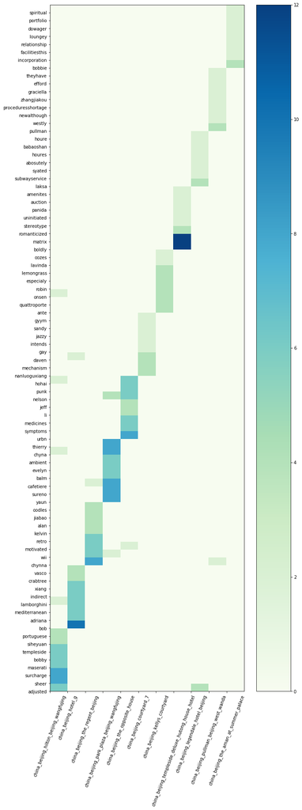

```python
HotelScores1 = []
Hotel1 = [17,7,10,0,44,92,105,110,132,102,126]
for hi in Hotel1:
    print(f'{hi}: {inverse_hotel[hi][0]},', end='')
    HotelScores1.append(tf_idf(hotel_vectors, hi))
print('\ndone')
select_wi1 = []
sorted_wi1 = []
tmp1 = lil_matrix((len(Hotel1),fixed_vocab_size), dtype=np.float)
for km, ks in enumerate(HotelScores1):
    for hi in ks[:8]:
        select_wi1.append(hi[1])
        if hi[1] not in sorted_wi1:
            sorted_wi1.append(hi[1])
        tmp1[km, hi[1]] = hi[7]

#select_wi=list(set(select_wi))
select_wi1 = [wi for wi,_ in Counter(select_wi1).most_common(500)]
print(len(select_wi1))

fig= plt.figure(figsize=(10,29))
ax = fig.add_subplot(1,1,1)
v4=hotel_vectors[:,select_wi1][Hotel1].toarray().T
plt.pcolormesh(v4, cmap=plt.cm.GnBu)
plt.yticks(np.arange(v4.shape[0]), [inverse_vocab[wi][0] for wi in csr_matrix(tmp1.sum(axis=0)).indices])
plt.xticks(np.arange(len(Hotel1)), [inverse_hotel[ki][0] for ki in Hotel1], rotation=70)
plt.colorbar()
fig.patch.set_facecolor('#FFFFFF')
plt.show()
```

```python
HotelScores1 = []
Hotel1 = [17,7,10,0,44,92,105,110,132,102,126]
for hi in Hotel1:
    print(f'{hi}: {inverse_hotel[hi][0]},', end='')
    HotelScores1.append(tf_idf(hotel_vectors, hi))
print('\ndone')
select_wi1 = []
sorted_wi1 = []
tmp1 = lil_matrix((len(Hotel1),fixed_vocab_size), dtype=np.float)
for km, ks in enumerate(HotelScores1):
    for hi in ks[:8]:
        select_wi1.append(hi[1])
        if hi[1] not in sorted_wi1:
            sorted_wi1.append(hi[1])
        tmp1[km, hi[1]] = hi[7]

#select_wi=list(set(select_wi))
select_wi1 = [wi for wi,_ in Counter(select_wi1).most_common(500)]
print(len(select_wi1))

fig= plt.figure(figsize=(10,29))
ax = fig.add_subplot(1,1,1)
v4=hotel_vectors[:,select_wi1][Hotel1].toarray().T
plt.pcolormesh(v4, cmap=plt.cm.GnBu)
plt.yticks(np.arange(v4.shape[0]), [inverse_vocab[wi][0] for wi in csr_matrix(tmp1.sum(axis=0)).indices])
plt.xticks(np.arange(len(Hotel1)), [inverse_hotel[ki][0] for ki in Hotel1], rotation=70)
plt.colorbar()
fig.patch.set_facecolor('#FFFFFF')
plt.show()
```

[output not shown]